# **Practice**

#### 2021/12/12

# **はじめてのR Markdown**

## **データセットの説明**

以下では、`mtcars`データセットを使って、R Markdownの練習をします。  
→ Rにプリインストールされている、車両性能に関するデータセット

まず`head(mtcars, 5)`と入力して、`mtcars`データセットの**冒頭5行**を表示しましょう。

```r
head(mtcars, 5)
```

```
##                    mpg cyl disp  hp drat    wt  qsec vs am gear carb
## Mazda RX4         21.0   6  160 110 3.90 2.620 16.46  0  1    4    4
## Mazda RX4 Wag     21.0   6  160 110 3.90 2.875 17.02  0  1    4    4
## Datsun 710        22.8   4  108  93 3.85 2.320 18.61  1  1    4    1
## Hornet 4 Drive    21.4   6  258 110 3.08 3.215 19.44  1  0    3    1
## Hornet Sportabout 18.7   8  360 175 3.15 3.440 17.02  0  0    3    2
```

## 主要な変数

- mpg
  - 燃費
- wt
  - 重量
- am
  - オートマ車(0)か、マニュアル車(1)か

## **可視化**

`mtcars`データセット内の`wt`変数の、**ヒストグラム**を描きます。

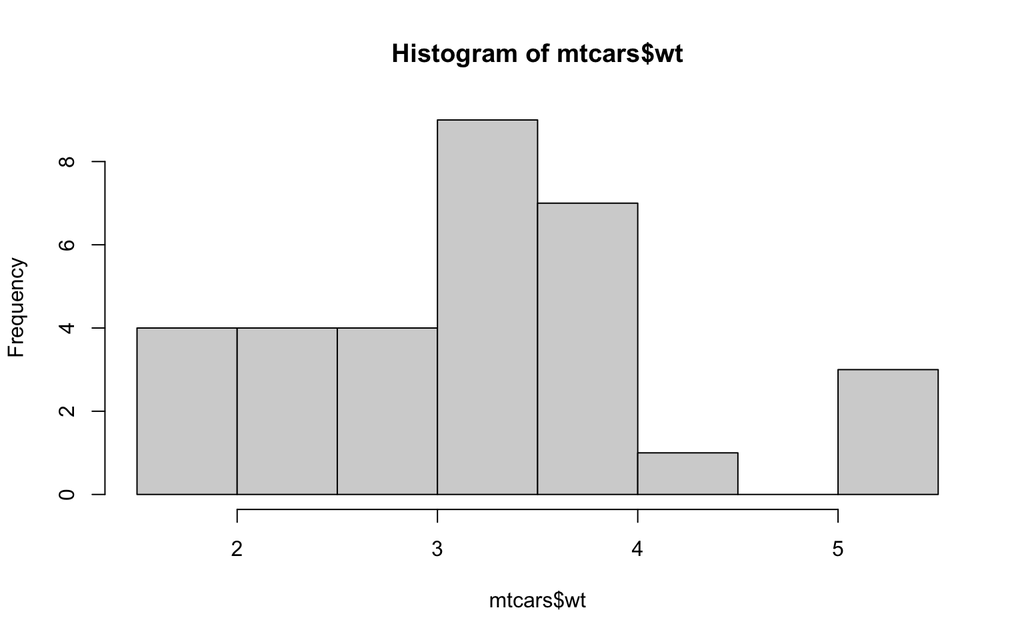

```r
hist(mtcars$wt)
```

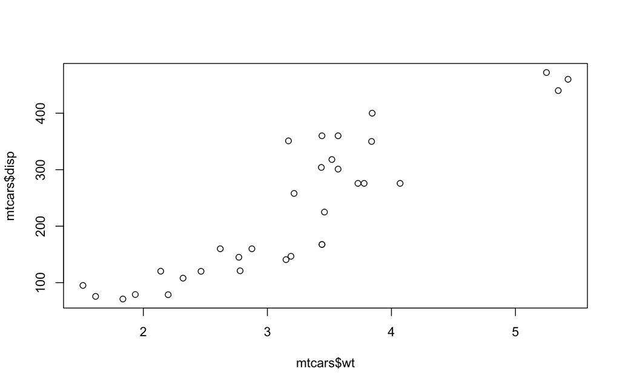

```r
plot(mtcars$wt, mtcars$disp)
```

```
plot(mtcars$mpg, mtcars$wt)
```

## **要約統計量**

例えば、`wt`変数の平均値は3.21725で、標準偏差は0.9784574ですね。

`mpg`変数と、`wt`変数、それぞれについて、平均・中央値・標準偏差を表にまとめてみましょう。

|  | 平均 | 中央値 | 標準偏差 |
| --- | --- | --- | --- |
| mpg | 20.090625 | 19.2 | 6.0269481 |
| wt | 3.21725 | 3.325 | 0.9784574 |

# **振り返り**

上手くできましたか？ まだまだ機能はたくさんあるので、使いこなしてくださいね。※上の画像は、以下のURLから取得可能です。

[figure not shown]

https://2.bp.blogspot.com/-Fh9ignfXzoY/VYJcboG8aAI/AAAAAAAAuYo/K0gRAJt4OC4/s800/message_otsukaresamadesu.png